# Risk Factor Analysis

## Outcome Variable

**Outcome Variable:** whz

## Predictor Variables

**Intervention Variable:** vagbrth

**Adjustment Set:**

unadjusted

## Stratifying Variables

The analysis was stratified on these variable(s):

- agecat
- studyid
- country

## Data Summary

| agecat | studyid | country | vagbrth | n_cell | n |
| --- | --- | --- | --- | --- | --- |
| Birth | CMC-V-BCS-2002 | INDIA | 0 | 10 | 86 |
| Birth | CMC-V-BCS-2002 | INDIA | 1 | 76 | 86 |
| Birth | IRC | INDIA | 0 | 66 | 343 |
| Birth | IRC | INDIA | 1 | 277 | 343 |
| Birth | JiVitA-3 | BANGLADESH | 0 | 500 | 17985 |
| Birth | JiVitA-3 | BANGLADESH | 1 | 17485 | 17985 |
| Birth | JiVitA-4 | BANGLADESH | 0 | 71 | 2395 |
| Birth | JiVitA-4 | BANGLADESH | 1 | 2324 | 2395 |
| Birth | NIH-Crypto | BANGLADESH | 0 | 184 | 465 |
| Birth | NIH-Crypto | BANGLADESH | 1 | 281 | 465 |
| Birth | PROBIT | BELARUS | 0 | 1591 | 13817 |
| Birth | PROBIT | BELARUS | 1 | 12226 | 13817 |
| Birth | PROVIDE | BANGLADESH | 0 | 108 | 532 |
| Birth | PROVIDE | BANGLADESH | 1 | 424 | 532 |
| Birth | ZVITAMBO | ZIMBABWE | 0 | 1100 | 12814 |
| Birth | ZVITAMBO | ZIMBABWE | 1 | 11714 | 12814 |
| 6 months | CMC-V-BCS-2002 | INDIA | 0 | 25 | 368 |
| 6 months | CMC-V-BCS-2002 | INDIA | 1 | 343 | 368 |
| 6 months | IRC | INDIA | 0 | 68 | 408 |
| 6 months | IRC | INDIA | 1 | 340 | 408 |
| 6 months | JiVitA-3 | BANGLADESH | 0 | 1075 | 16705 |
| 6 months | JiVitA-3 | BANGLADESH | 1 | 15630 | 16705 |
| 6 months | JiVitA-4 | BANGLADESH | 0 | 337 | 4056 |
| 6 months | JiVitA-4 | BANGLADESH | 1 | 3719 | 4056 |
| 6 months | NIH-Crypto | BANGLADESH | 0 | 187 | 457 |
| 6 months | NIH-Crypto | BANGLADESH | 1 | 270 | 457 |
| 6 months | PROBIT | BELARUS | 0 | 1797 | 15757 |
| 6 months | PROBIT | BELARUS | 1 | 13960 | 15757 |
| 6 months | PROVIDE | BANGLADESH | 0 | 139 | 603 |
| 6 months | PROVIDE | BANGLADESH | 1 | 464 | 603 |
| 6 months | TanzaniaChild2 | TANZANIA, UNITED REPUBLIC OF | 0 | 189 | 2004 |
| 6 months | TanzaniaChild2 | TANZANIA, UNITED REPUBLIC OF | 1 | 1815 | 2004 |
| 6 months | ZVITAMBO | ZIMBABWE | 0 | 721 | 8437 |
| 6 months | ZVITAMBO | ZIMBABWE | 1 | 7716 | 8437 |
| 24 months | CMC-V-BCS-2002 | INDIA | 0 | 25 | 372 |
| 24 months | CMC-V-BCS-2002 | INDIA | 1 | 347 | 372 |
| 24 months | IRC | INDIA | 0 | 69 | 409 |
| 24 months | IRC | INDIA | 1 | 340 | 409 |
| 24 months | JiVitA-3 | BANGLADESH | 0 | 475 | 8555 |
| 24 months | JiVitA-3 | BANGLADESH | 1 | 8080 | 8555 |
| 24 months | JiVitA-4 | BANGLADESH | 0 | 323 | 4008 |
| 24 months | JiVitA-4 | BANGLADESH | 1 | 3685 | 4008 |
| 24 months | NIH-Crypto | BANGLADESH | 0 | 99 | 260 |
| 24 months | NIH-Crypto | BANGLADESH | 1 | 161 | 260 |
| 24 months | PROBIT | BELARUS | 0 | 463 | 3970 |
| 24 months | PROBIT | BELARUS | 1 | 3507 | 3970 |
| 24 months | PROVIDE | BANGLADESH | 0 | 137 | 579 |
| 24 months | PROVIDE | BANGLADESH | 1 | 442 | 579 |
| 24 months | TanzaniaChild2 | TANZANIA, UNITED REPUBLIC OF | 0 | 2 | 6 |
| 24 months | TanzaniaChild2 | TANZANIA, UNITED REPUBLIC OF | 1 | 4 | 6 |
| 24 months | ZVITAMBO | ZIMBABWE | 0 | 28 | 426 |
| 24 months | ZVITAMBO | ZIMBABWE | 1 | 398 | 426 |

The following strata were considered:

- agecat: 24 months, studyid: CMC-V-BCS-2002, country: INDIA
- agecat: 24 months, studyid: IRC, country: INDIA
- agecat: 24 months, studyid: JiVitA-3, country: BANGLADESH
- agecat: 24 months, studyid: JiVitA-4, country: BANGLADESH
- agecat: 24 months, studyid: NIH-Crypto, country: BANGLADESH
- agecat: 24 months, studyid: PROBIT, country: BELARUS
- agecat: 24 months, studyid: PROVIDE, country: BANGLADESH
- agecat: 24 months, studyid: TanzaniaChild2, country: TANZANIA, UNITED REPUBLIC OF
- agecat: 24 months, studyid: ZVITAMBO, country: ZIMBABWE
- agecat: 6 months, studyid: CMC-V-BCS-2002, country: INDIA
- agecat: 6 months, studyid: IRC, country: INDIA
- agecat: 6 months, studyid: JiVitA-3, country: BANGLADESH
- agecat: 6 months, studyid: JiVitA-4, country: BANGLADESH
- agecat: 6 months, studyid: NIH-Crypto, country: BANGLADESH
- agecat: 6 months, studyid: PROBIT, country: BELARUS
- agecat: 6 months, studyid: PROVIDE, country: BANGLADESH
- agecat: 6 months, studyid: TanzaniaChild2, country: TANZANIA, UNITED REPUBLIC OF
- agecat: 6 months, studyid: ZVITAMBO, country: ZIMBABWE
- agecat: Birth, studyid: CMC-V-BCS-2002, country: INDIA
- agecat: Birth, studyid: IRC, country: INDIA
- agecat: Birth, studyid: JiVitA-3, country: BANGLADESH
- agecat: Birth, studyid: JiVitA-4, country: BANGLADESH
- agecat: Birth, studyid: NIH-Crypto, country: BANGLADESH
- agecat: Birth, studyid: PROBIT, country: BELARUS
- agecat: Birth, studyid: PROVIDE, country: BANGLADESH
- agecat: Birth, studyid: ZVITAMBO, country: ZIMBABWE

### Dropped Strata

Some strata were dropped due to rare outcomes:

- agecat: 24 months, studyid: TanzaniaChild2, country: TANZANIA, UNITED REPUBLIC OF

## Methods Detail

We’re interested in the causal parameters $E[Y_a]$ for all values of $a \in \mathcal{A}$. These parameters represent the mean outcome if, possibly contrary to fact, we intervened to set all units to have $A=a$. Under the randomization and positivity assumptions, these are identified by the statistical parameters $\psi_a=E_W[E_{Y|A,W}(Y|A=a,W)]$. In addition, we’re interested in the mean of $Y$, $E[Y]$ under no intervention (the observed mean). We will estimate these parameters by using SuperLearner to fit the relevant likelihood factors – $E_{Y|A,W}(Y|A=a,W)$ and $p(A=a|W)$, and then updating our likelihood fit using a joint TMLE.

For unadjusted analyses ($W=\{\}$), initial likelihoods were estimated using Lrnr_glm to estimate the simple $E(Y|A)$ and Lrnr_mean to estimate $p(A)$. For adjusted analyses, a small library containing Lrnr_glmnet, Lrnr_xgboost, and Lrnr_mean was used.

Having estimated these parameters, we will then use the delta method to estimate relative risks and attributable risks relative to a prespecified baseline level of $A$.

# Results Detail

## Results Plots

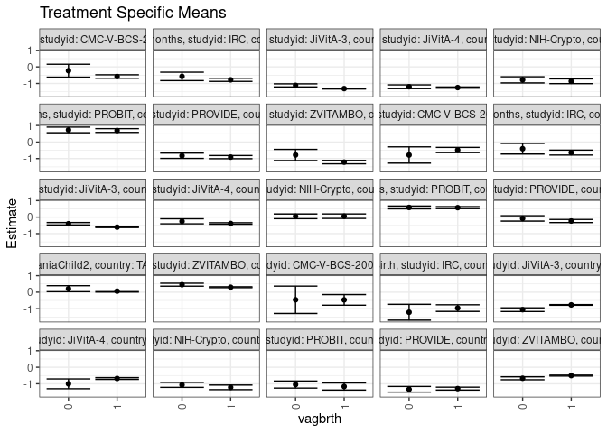

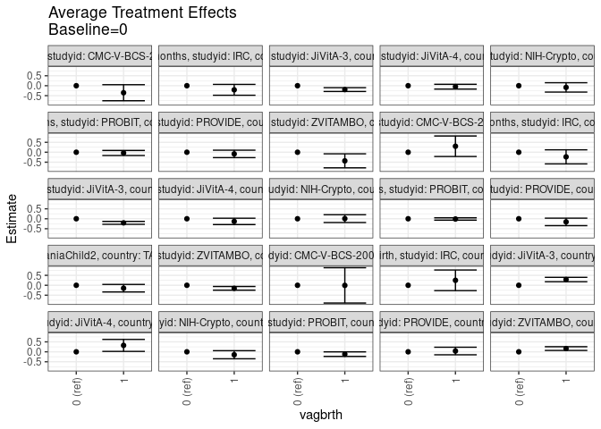

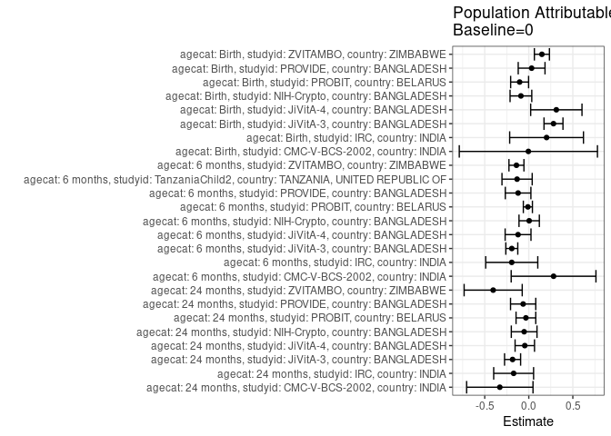

## Results Table

### Parameter: TSM

| agecat | studyid | country | intervention_level | baseline_level | estimate | ci_lower | ci_upper |
| --- | --- | --- | --- | --- | --- | --- | --- |
| Birth | CMC-V-BCS-2002 | INDIA | 0 | NA | -0.4600000 | -1.2873180 | 0.3673180 |
| Birth | CMC-V-BCS-2002 | INDIA | 1 | NA | -0.4654605 | -0.7864043 | -0.1445168 |
| Birth | IRC | INDIA | 0 | NA | -1.2124242 | -1.6904143 | -0.7344342 |
| Birth | IRC | INDIA | 1 | NA | -0.9624910 | -1.1632871 | -0.7616949 |
| Birth | JiVitA-3 | BANGLADESH | 0 | NA | -1.0578600 | -1.1677250 | -0.9479950 |
| Birth | JiVitA-3 | BANGLADESH | 1 | NA | -0.7694550 | -0.7885833 | -0.7503266 |
| Birth | JiVitA-4 | BANGLADESH | 0 | NA | -1.0016901 | -1.2972735 | -0.7061068 |
| Birth | JiVitA-4 | BANGLADESH | 1 | NA | -0.6794664 | -0.7325903 | -0.6263426 |
| Birth | NIH-Crypto | BANGLADESH | 0 | NA | -1.0656522 | -1.2144509 | -0.9168535 |
| Birth | NIH-Crypto | BANGLADESH | 1 | NA | -1.2134698 | -1.3524110 | -1.0745285 |
| Birth | PROBIT | BELARUS | 0 | NA | -1.0451791 | -1.2589715 | -0.8313868 |
| Birth | PROBIT | BELARUS | 1 | NA | -1.1627118 | -1.3756573 | -0.9497664 |
| Birth | PROVIDE | BANGLADESH | 0 | NA | -1.3305556 | -1.5007710 | -1.1603402 |
| Birth | PROVIDE | BANGLADESH | 1 | NA | -1.2902830 | -1.3763471 | -1.2042189 |
| Birth | ZVITAMBO | ZIMBABWE | 0 | NA | -0.6656545 | -0.7550904 | -0.5762187 |
| Birth | ZVITAMBO | ZIMBABWE | 1 | NA | -0.5029187 | -0.5300485 | -0.4757890 |
| 6 months | CMC-V-BCS-2002 | INDIA | 0 | NA | -0.7840000 | -1.2754181 | -0.2925819 |
| 6 months | CMC-V-BCS-2002 | INDIA | 1 | NA | -0.4821720 | -0.6399577 | -0.3243863 |
| 6 months | IRC | INDIA | 0 | NA | -0.4054657 | -0.7270836 | -0.0838478 |
| 6 months | IRC | INDIA | 1 | NA | -0.6376225 | -0.7866428 | -0.4886023 |
| 6 months | JiVitA-3 | BANGLADESH | 0 | NA | -0.4006233 | -0.4728476 | -0.3283989 |
| 6 months | JiVitA-3 | BANGLADESH | 1 | NA | -0.6067732 | -0.6264409 | -0.5871055 |
| 6 months | JiVitA-4 | BANGLADESH | 0 | NA | -0.2540208 | -0.4065393 | -0.1015023 |
| 6 months | JiVitA-4 | BANGLADESH | 1 | NA | -0.3868392 | -0.4315827 | -0.3420957 |
| 6 months | NIH-Crypto | BANGLADESH | 0 | NA | 0.0470856 | -0.0942784 | 0.1884495 |
| 6 months | NIH-Crypto | BANGLADESH | 1 | NA | 0.0546481 | -0.0802475 | 0.1895438 |
| 6 months | PROBIT | BELARUS | 0 | NA | 0.5844908 | 0.5001218 | 0.6688598 |
| 6 months | PROBIT | BELARUS | 1 | NA | 0.5727736 | 0.5132897 | 0.6322575 |
| 6 months | PROVIDE | BANGLADESH | 0 | NA | -0.0776739 | -0.2404900 | 0.0851423 |
| 6 months | PROVIDE | BANGLADESH | 1 | NA | -0.2354634 | -0.3309929 | -0.1399338 |
| 6 months | TanzaniaChild2 | TANZANIA, UNITED REPUBLIC OF | 0 | NA | 0.2098104 | 0.0286733 | 0.3909476 |
| 6 months | TanzaniaChild2 | TANZANIA, UNITED REPUBLIC OF | 1 | NA | 0.0631019 | 0.0079444 | 0.1182595 |
| 6 months | ZVITAMBO | ZIMBABWE | 0 | NA | 0.4517060 | 0.3626668 | 0.5407451 |
| 6 months | ZVITAMBO | ZIMBABWE | 1 | NA | 0.2985277 | 0.2716096 | 0.3254459 |
| 24 months | CMC-V-BCS-2002 | INDIA | 0 | NA | -0.2282667 | -0.6182771 | 0.1617437 |
| 24 months | CMC-V-BCS-2002 | INDIA | 1 | NA | -0.5808453 | -0.6853852 | -0.4763054 |
| 24 months | IRC | INDIA | 0 | NA | -0.5738406 | -0.8284955 | -0.3191857 |
| 24 months | IRC | INDIA | 1 | NA | -0.7807157 | -0.8767956 | -0.6846357 |
| 24 months | JiVitA-3 | BANGLADESH | 0 | NA | -1.1144211 | -1.2085136 | -1.0203285 |
| 24 months | JiVitA-3 | BANGLADESH | 1 | NA | -1.3092079 | -1.3330486 | -1.2853672 |
| 24 months | JiVitA-4 | BANGLADESH | 0 | NA | -1.1980186 | -1.3132431 | -1.0827940 |
| 24 months | JiVitA-4 | BANGLADESH | 1 | NA | -1.2473406 | -1.2828135 | -1.2118676 |
| 24 months | NIH-Crypto | BANGLADESH | 0 | NA | -0.7817172 | -0.9679615 | -0.5954729 |
| 24 months | NIH-Crypto | BANGLADESH | 1 | NA | -0.8666460 | -1.0104018 | -0.7228901 |
| 24 months | PROBIT | BELARUS | 0 | NA | 0.7308639 | 0.5607815 | 0.9009463 |
| 24 months | PROBIT | BELARUS | 1 | NA | 0.6938205 | 0.5811319 | 0.8065091 |
| 24 months | PROVIDE | BANGLADESH | 0 | NA | -0.8289051 | -0.9900203 | -0.6677899 |
| 24 months | PROVIDE | BANGLADESH | 1 | NA | -0.9126923 | -1.0086772 | -0.8167074 |
| 24 months | ZVITAMBO | ZIMBABWE | 0 | NA | -0.7821429 | -1.1191711 | -0.4451146 |
| 24 months | ZVITAMBO | ZIMBABWE | 1 | NA | -1.2148744 | -1.3188518 | -1.1108969 |

### Parameter: E(Y)

| agecat | studyid | country | intervention_level | baseline_level | estimate | ci_lower | ci_upper |
| --- | --- | --- | --- | --- | --- | --- | --- |
| Birth | CMC-V-BCS-2002 | INDIA | NA | NA | -0.4648256 | -0.7643210 | -0.1653302 |
| Birth | IRC | INDIA | NA | NA | -1.0105831 | -1.1973019 | -0.8238643 |
| Birth | JiVitA-3 | BANGLADESH | NA | NA | -0.7774729 | -0.7964631 | -0.7584827 |
| Birth | JiVitA-4 | BANGLADESH | NA | NA | -0.6890188 | -0.7414800 | -0.6365575 |
| Birth | NIH-Crypto | BANGLADESH | NA | NA | -1.1549785 | -1.2577390 | -1.0522180 |
| Birth | PROBIT | BELARUS | NA | NA | -1.1491782 | -1.3593933 | -0.9389630 |
| Birth | PROVIDE | BANGLADESH | NA | NA | -1.2984586 | -1.3752758 | -1.2216415 |
| Birth | ZVITAMBO | ZIMBABWE | NA | NA | -0.5168886 | -0.5428625 | -0.4909146 |
| 6 months | CMC-V-BCS-2002 | INDIA | NA | NA | -0.5026766 | -0.6536848 | -0.3516685 |
| 6 months | IRC | INDIA | NA | NA | -0.5989297 | -0.7344491 | -0.4634104 |
| 6 months | JiVitA-3 | BANGLADESH | NA | NA | -0.5935070 | -0.6130727 | -0.5739413 |
| 6 months | JiVitA-4 | BANGLADESH | NA | NA | -0.3758037 | -0.4184544 | -0.3331531 |
| 6 months | NIH-Crypto | BANGLADESH | NA | NA | 0.0515536 | -0.0469240 | 0.1500313 |
| 6 months | PROBIT | BELARUS | NA | NA | 0.5741099 | 0.5141290 | 0.6340908 |
| 6 months | PROVIDE | BANGLADESH | NA | NA | -0.1990907 | -0.2817968 | -0.1163845 |
| 6 months | TanzaniaChild2 | TANZANIA, UNITED REPUBLIC OF | NA | NA | 0.0769382 | 0.0241090 | 0.1297674 |
| 6 months | ZVITAMBO | ZIMBABWE | NA | NA | 0.3116179 | 0.2858347 | 0.3374010 |
| 24 months | CMC-V-BCS-2002 | INDIA | NA | NA | -0.5571505 | -0.6585247 | -0.4557763 |
| 24 months | IRC | INDIA | NA | NA | -0.7458150 | -0.8368180 | -0.6548120 |
| 24 months | JiVitA-3 | BANGLADESH | NA | NA | -1.2983928 | -1.3216893 | -1.2750962 |
| 24 months | JiVitA-4 | BANGLADESH | NA | NA | -1.2433658 | -1.2774681 | -1.2092634 |
| 24 months | NIH-Crypto | BANGLADESH | NA | NA | -0.8343077 | -0.9482310 | -0.7203844 |
| 24 months | PROBIT | BELARUS | NA | NA | 0.6981406 | 0.5843775 | 0.8119038 |
| 24 months | PROVIDE | BANGLADESH | NA | NA | -0.8928670 | -0.9755153 | -0.8102187 |
| 24 months | ZVITAMBO | ZIMBABWE | NA | NA | -1.1864319 | -1.2865891 | -1.0862748 |

### Parameter: ATE

| agecat | studyid | country | intervention_level | baseline_level | estimate | ci_lower | ci_upper |
| --- | --- | --- | --- | --- | --- | --- | --- |
| Birth | CMC-V-BCS-2002 | INDIA | 0 | 0 | 0.0000000 | 0.0000000 | 0.0000000 |
| Birth | CMC-V-BCS-2002 | INDIA | 1 | 0 | -0.0054605 | -0.8928499 | 0.8819289 |
| Birth | IRC | INDIA | 0 | 0 | 0.0000000 | 0.0000000 | 0.0000000 |
| Birth | IRC | INDIA | 1 | 0 | 0.2499333 | -0.2685198 | 0.7683863 |
| Birth | JiVitA-3 | BANGLADESH | 0 | 0 | 0.0000000 | 0.0000000 | 0.0000000 |
| Birth | JiVitA-3 | BANGLADESH | 1 | 0 | 0.2884050 | 0.1776286 | 0.3991815 |
| Birth | JiVitA-4 | BANGLADESH | 0 | 0 | 0.0000000 | 0.0000000 | 0.0000000 |
| Birth | JiVitA-4 | BANGLADESH | 1 | 0 | 0.3222237 | 0.0215004 | 0.6229470 |
| Birth | NIH-Crypto | BANGLADESH | 0 | 0 | 0.0000000 | 0.0000000 | 0.0000000 |
| Birth | NIH-Crypto | BANGLADESH | 1 | 0 | -0.1478176 | -0.3513998 | 0.0557646 |
| Birth | PROBIT | BELARUS | 0 | 0 | 0.0000000 | 0.0000000 | 0.0000000 |
| Birth | PROBIT | BELARUS | 1 | 0 | -0.1175327 | -0.2322204 | -0.0028451 |
| Birth | PROVIDE | BANGLADESH | 0 | 0 | 0.0000000 | 0.0000000 | 0.0000000 |
| Birth | PROVIDE | BANGLADESH | 1 | 0 | 0.0402725 | -0.1504637 | 0.2310088 |
| Birth | ZVITAMBO | ZIMBABWE | 0 | 0 | 0.0000000 | 0.0000000 | 0.0000000 |
| Birth | ZVITAMBO | ZIMBABWE | 1 | 0 | 0.1627358 | 0.0692757 | 0.2561960 |
| 6 months | CMC-V-BCS-2002 | INDIA | 0 | 0 | 0.0000000 | 0.0000000 | 0.0000000 |
| 6 months | CMC-V-BCS-2002 | INDIA | 1 | 0 | 0.3018280 | -0.2142999 | 0.8179559 |
| 6 months | IRC | INDIA | 0 | 0 | 0.0000000 | 0.0000000 | 0.0000000 |
| 6 months | IRC | INDIA | 1 | 0 | -0.2321569 | -0.5866214 | 0.1223077 |
| 6 months | JiVitA-3 | BANGLADESH | 0 | 0 | 0.0000000 | 0.0000000 | 0.0000000 |
| 6 months | JiVitA-3 | BANGLADESH | 1 | 0 | -0.2061499 | -0.2789263 | -0.1333736 |
| 6 months | JiVitA-4 | BANGLADESH | 0 | 0 | 0.0000000 | 0.0000000 | 0.0000000 |
| 6 months | JiVitA-4 | BANGLADESH | 1 | 0 | -0.1328184 | -0.2926964 | 0.0270595 |
| 6 months | NIH-Crypto | BANGLADESH | 0 | 0 | 0.0000000 | 0.0000000 | 0.0000000 |
| 6 months | NIH-Crypto | BANGLADESH | 1 | 0 | 0.0075626 | -0.1878360 | 0.2029612 |
| 6 months | PROBIT | BELARUS | 0 | 0 | 0.0000000 | 0.0000000 | 0.0000000 |
| 6 months | PROBIT | BELARUS | 1 | 0 | -0.0117172 | -0.0699826 | 0.0465482 |
| 6 months | PROVIDE | BANGLADESH | 0 | 0 | 0.0000000 | 0.0000000 | 0.0000000 |
| 6 months | PROVIDE | BANGLADESH | 1 | 0 | -0.1577895 | -0.3465618 | 0.0309828 |
| 6 months | TanzaniaChild2 | TANZANIA, UNITED REPUBLIC OF | 0 | 0 | 0.0000000 | 0.0000000 | 0.0000000 |
| 6 months | TanzaniaChild2 | TANZANIA, UNITED REPUBLIC OF | 1 | 0 | -0.1467085 | -0.3360574 | 0.0426405 |
| 6 months | ZVITAMBO | ZIMBABWE | 0 | 0 | 0.0000000 | 0.0000000 | 0.0000000 |
| 6 months | ZVITAMBO | ZIMBABWE | 1 | 0 | -0.1531782 | -0.2461974 | -0.0601591 |
| 24 months | CMC-V-BCS-2002 | INDIA | 0 | 0 | 0.0000000 | 0.0000000 | 0.0000000 |
| 24 months | CMC-V-BCS-2002 | INDIA | 1 | 0 | -0.3525787 | -0.7563567 | 0.0511994 |
| 24 months | IRC | INDIA | 0 | 0 | 0.0000000 | 0.0000000 | 0.0000000 |
| 24 months | IRC | INDIA | 1 | 0 | -0.2068751 | -0.4790524 | 0.0653022 |
| 24 months | JiVitA-3 | BANGLADESH | 0 | 0 | 0.0000000 | 0.0000000 | 0.0000000 |
| 24 months | JiVitA-3 | BANGLADESH | 1 | 0 | -0.1947869 | -0.2913989 | -0.0981748 |
| 24 months | JiVitA-4 | BANGLADESH | 0 | 0 | 0.0000000 | 0.0000000 | 0.0000000 |
| 24 months | JiVitA-4 | BANGLADESH | 1 | 0 | -0.0493220 | -0.1692863 | 0.0706423 |
| 24 months | NIH-Crypto | BANGLADESH | 0 | 0 | 0.0000000 | 0.0000000 | 0.0000000 |
| 24 months | NIH-Crypto | BANGLADESH | 1 | 0 | -0.0849288 | -0.3202003 | 0.1503427 |
| 24 months | PROBIT | BELARUS | 0 | 0 | 0.0000000 | 0.0000000 | 0.0000000 |
| 24 months | PROBIT | BELARUS | 1 | 0 | -0.0370435 | -0.1638844 | 0.0897974 |
| 24 months | PROVIDE | BANGLADESH | 0 | 0 | 0.0000000 | 0.0000000 | 0.0000000 |
| 24 months | PROVIDE | BANGLADESH | 1 | 0 | -0.0837872 | -0.2713271 | 0.1037527 |
| 24 months | ZVITAMBO | ZIMBABWE | 0 | 0 | 0.0000000 | 0.0000000 | 0.0000000 |
| 24 months | ZVITAMBO | ZIMBABWE | 1 | 0 | -0.4327315 | -0.7854345 | -0.0800286 |

### Parameter: PAR

| agecat | studyid | country | intervention_level | baseline_level | estimate | ci_lower | ci_upper |
| --- | --- | --- | --- | --- | --- | --- | --- |
| Birth | CMC-V-BCS-2002 | INDIA | 0 | NA | -0.0048256 | -0.7890302 | 0.7793791 |
| Birth | IRC | INDIA | 0 | NA | 0.2018412 | -0.2169814 | 0.6206638 |
| Birth | JiVitA-3 | BANGLADESH | 0 | NA | 0.2803871 | 0.1728024 | 0.3879718 |
| Birth | JiVitA-4 | BANGLADESH | 0 | NA | 0.3126714 | 0.0214782 | 0.6038645 |
| Birth | NIH-Crypto | BANGLADESH | 0 | NA | -0.0893263 | -0.2125269 | 0.0338743 |
| Birth | PROBIT | BELARUS | 0 | NA | -0.1039991 | -0.2058327 | -0.0021654 |
| Birth | PROVIDE | BANGLADESH | 0 | NA | 0.0320969 | -0.1199247 | 0.1841185 |
| Birth | ZVITAMBO | ZIMBABWE | 0 | NA | 0.1487660 | 0.0633251 | 0.2342068 |
| 6 months | CMC-V-BCS-2002 | INDIA | 0 | NA | 0.2813234 | -0.1998043 | 0.7624510 |
| 6 months | IRC | INDIA | 0 | NA | -0.1934641 | -0.4889707 | 0.1020426 |
| 6 months | JiVitA-3 | BANGLADESH | 0 | NA | -0.1928838 | -0.2608415 | -0.1249261 |
| 6 months | JiVitA-4 | BANGLADESH | 0 | NA | -0.1217830 | -0.2685214 | 0.0249554 |
| 6 months | NIH-Crypto | BANGLADESH | 0 | NA | 0.0044680 | -0.1109758 | 0.1199119 |
| 6 months | PROBIT | BELARUS | 0 | NA | -0.0103809 | -0.0619403 | 0.0411785 |
| 6 months | PROVIDE | BANGLADESH | 0 | NA | -0.1214168 | -0.2667714 | 0.0239378 |
| 6 months | TanzaniaChild2 | TANZANIA, UNITED REPUBLIC OF | 0 | NA | -0.1328722 | -0.3043737 | 0.0386293 |
| 6 months | ZVITAMBO | ZIMBABWE | 0 | NA | -0.1400881 | -0.2251630 | -0.0550132 |
| 24 months | CMC-V-BCS-2002 | INDIA | 0 | NA | -0.3288839 | -0.7056334 | 0.0478657 |
| 24 months | IRC | INDIA | 0 | NA | -0.1719744 | -0.3983591 | 0.0544103 |
| 24 months | JiVitA-3 | BANGLADESH | 0 | NA | -0.1839717 | -0.2751207 | -0.0928227 |
| 24 months | JiVitA-4 | BANGLADESH | 0 | NA | -0.0453472 | -0.1555891 | 0.0648947 |
| 24 months | NIH-Crypto | BANGLADESH | 0 | NA | -0.0525905 | -0.1983644 | 0.0931834 |
| 24 months | PROBIT | BELARUS | 0 | NA | -0.0327233 | -0.1446478 | 0.0792012 |
| 24 months | PROVIDE | BANGLADESH | 0 | NA | -0.0639619 | -0.2071565 | 0.0792327 |
| 24 months | ZVITAMBO | ZIMBABWE | 0 | NA | -0.4042891 | -0.7339673 | -0.0746108 |